# Life Expectancy Data Analysis

STAT 420, Summer 2023, Maxim Aldaranov, Alice Fu, Scott Girten

08/04/23

```r
library(ggplot2)
library(GGally)
library(patchwork)
library(readr)
library(tidyverse)
library(lmtest)
```

# Introduction

The purpose of this analysis is to fit a model that accurately predicts the average life expectancy based on various factors. The appropriate data was found to be analyzed. Different statistical methods will be applied to the data in order to reach the best model for the given purpose. It will allow us to determine interactions between the average life expectancy and the various factors affecting it, hence, helping us to determine the variables that accurately predict the average life expectancy.

## Dataset Information

The data represents the research on the average life expectancy in 178 countries over a 15-year period (2000-2015) from the World Health Organization. It includes economic, social and healthcare related factors affecting the average life expectancy. The data contains `21` variables and `2,864` observations. It was retrieved from [Kaggle](https://www.kaggle.com/datasets/lashagoch/life-expectancy-who-updated).

- `Country` - country of the sample
- `Region` - region of the sample
- `Year` - year of the sample
- `infant_deaths` - the number of infant deaths per 1000 people
- `Under_five_deaths` - the number of deaths of people under 5 years old per 1000 people
- `Adult_mortality` - the number of deaths per 1000 people between the ages of 15 years of age to 60 years of age
- `Alcohol_consumption` - alcohol consumption that is recorded in liters of pure alcohol per capita with 15+ years old
- `Hepatitis_B` - % of coverage of Hepatitis B (HepB3) immunization among 1-year-olds
- `Measles` - % of coverage of Measles containing vaccine first dose (MCV1) immunization among 1-year-olds
- `BMI` - measure of nutritional status in adults. It is defined as a person’s weight in kilograms divided by the square of that person’s height in meters (kg/m2)
- `Polio` - % of 1-year-olds immunized against polio
- `Diphtheria` - % of of 1-year-olds who were immunized against diphtheria
- `Incidents_HIV` - the number of deaths caused by AIDS of the last 4-year-olds who were born alive per 1000 people
- `GDP_per_capita` - gross domestic product per capita
- `Population_min` - total population in millions
- `Thinness_ten_nineteen_years` - prevalence of thinness among adolescents aged 10-19 years. BMI < -2 standard deviations below the median.
- `Thinness_five_nine_years` - prevalence of thinness among children aged 5-9 years. BMI < -2 standard deviations below the median.
- `Schooling` - average years that people aged 25+ spent in formal education
- `Economy_status_Developed` - developed country or not
- `Economy_status_Developing` - developing country or not
- `Life_expectancy` - average life expectancy of both genders in different years from 2010 to 2015

# Methods

## Data Cleaning

- Read the data from the file

```r
data_raw = read.csv("Life-Expectancy-Data-Updated.csv")
```

- Check any missing data

```r
ifelse(sum(is.na(data_raw)) == 0, "The data is complete", "The data is incomplete")
```

```
## [1] "The data is complete"
```

- One of the `Economy_status_Developed` and `Economy_status_Developing` variables is redundant. They can be combined in one variable

```r
head(subset(data_raw, select = c("Economy_status_Developed", "Economy_status_Developing")), 5)
```

```
##   Economy_status_Developed Economy_status_Developing
## 1                        0                         1
## 2                        1                         0
## 3                        0                         1
## 4                        0                         1
## 5                        1                         0
```

- We decide to keep `Economy_status_Developed` variable where the value `1` indicates a developed country and `0` indicates a country that is still developing. For simplicity, we renamed the `Economy_status_Developed` variable to `Developed`

```r
data = subset(data_raw, select = -c(Economy_status_Developing))
names(data)[names(data) == 'Economy_status_Developed'] = 'Developed'
```

- Since we are interested in a model predicting **global** average life expectancy omitted the variables `Country` and `Region`

```r
data = subset(data, select = -c(Country, Region)) #Year
```

- We convert *character* variable `Developed` and the *integer* variable `Year` to *factor* type in order to use them as categorical variable in the further analysis.

```r
data$Developed = as.factor(data$Developed)
data$Year = as.factor(data$Year)
```

## Cleaned Data Overview

- View the correlation matrix graph and table of the cleaned data

```r
# takes a long time to load, will need this for the Methods Section
# ggpairs(subset(data, select = -c(Year, Developed)))
```

```r
pairs_data = data.frame(Life_expectancy = data$Life_expectancy, GDP_per_capita = data$GDP_per_capita, log_GDP= log(data$GDP_per_capita), log2_GDP = log(log(data$GDP_per_capita)))

transform_GDP = ggpairs(pairs_data)


pairs_data = data.frame(subset(data, select = c(Life_expectancy, Hepatitis_B)), log_Hepatitis_B = log(data$Hepatitis_B), poly_Hepatits_B = poly(data$Hepatitis_B, 2))

transform_HepB = ggpairs(pairs_data)


pairs_data = data.frame(subset(data, select = c(Life_expectancy, Diphtheria)), log_Diphtheria = log(data$Diphtheria), poly_Diphtheria = poly(data$Diphtheria, 2))

transform_Diph = ggpairs(pairs_data)


pairs_data = data.frame(subset(data, select = c(Life_expectancy, Schooling)), log_ = log(data$Schooling), poly_ = poly(data$Schooling, 2))

transform_Schooling = ggpairs(pairs_data)


pairs_data = data.frame(subset(data, select = c(Life_expectancy, Incidents_HIV)), log_ = log(data$Incidents_HIV), poly_ = poly(data$Incidents_HIV, 2))

transform_hiv = ggpairs(pairs_data)


pairs_data = data.frame(subset(data, select = c(Life_expectancy, Under_five_deaths)), log_ = log(data$Under_five_deaths), poly_ = poly(data$Under_five_deaths, 2))

transform_under5 = ggpairs(pairs_data)
```

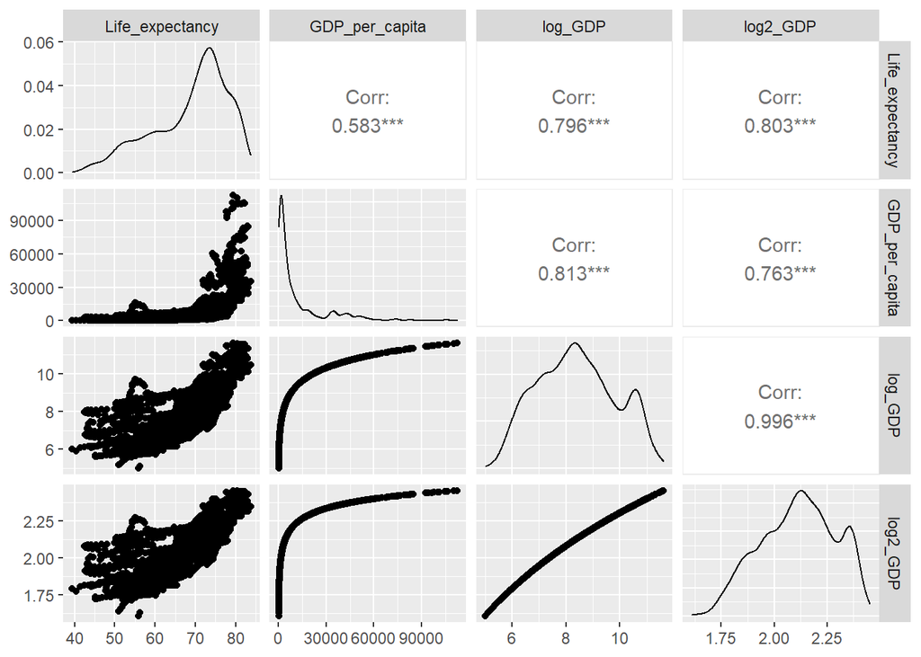

```r
transform_GDP # log2 > log >> x, only minor improvement from log to log2
```

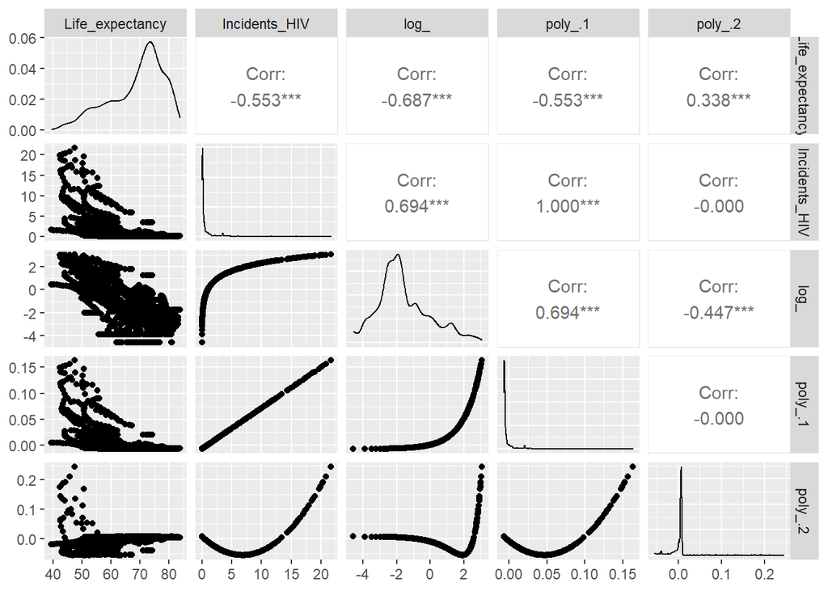

```r
# transform_HepB  # no improvements

# transform_Diph # no improvements

# transform_Schooling # no improvements

transform_hiv # slight improvement with log?
```

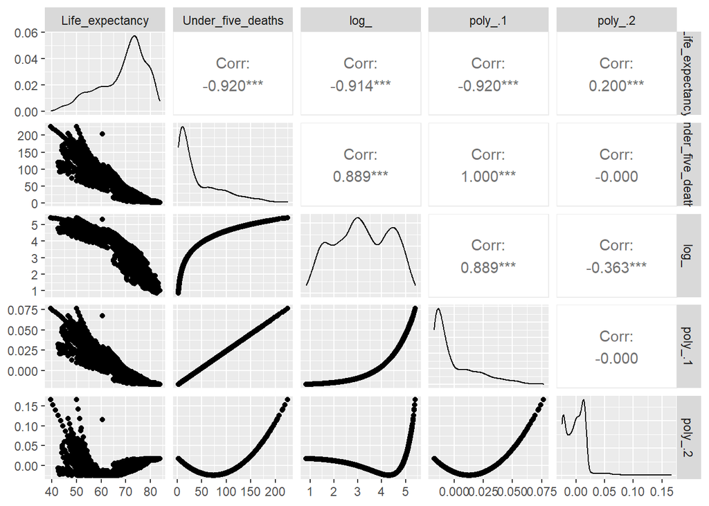

```r
transform_under5 # no improvements?
```

## Train and Test Data Separation

```r
set.seed(42)
sample = sample(c(TRUE, FALSE), nrow(data), replace=TRUE, prob=c(0.7,0.3))
data_trn = data[sample, ]
data_tst = data[!sample, ]
```

## Additive Model

```r
add_mod_full = lm(Life_expectancy ~ . - GDP_per_capita + log(GDP_per_capita), data = data_trn)

# add_vif = high_vif(add_mod_full)
# Infant_deaths & Under_five_deaths,  Polio & Diphtheria, Thinness_ten_nineteen_years & Thinness_five_nine_years

# Infant_deaths & Under_five_deaths
cor(data_trn$Infant_deaths, data_trn$Under_five_deaths) # very high
```

```
## [1] 0.9862
```

```r
infant_deaths_mod = lm(Infant_deaths ~ . - Life_expectancy, data = data_trn)
add_mod_wo_infant = lm(Life_expectancy ~ . - Infant_deaths, data = data_trn)

cor(resid(infant_deaths_mod), resid(add_mod_wo_infant)) # low -0.1337
```

```
## [1] -0.1337
```

```r
## Remove Infant_deaths


# Thinness_five_nine_years & Thinness_ten_nineteen_years
cor(data_trn$Thinness_five_nine_years, data_trn$Thinness_ten_nineteen_years) # high
```

```
## [1] 0.9413
```

```r
thiness_5_mod = lm(Thinness_five_nine_years  ~ . - Life_expectancy - Infant_deaths, data = data_trn)
add_mod_wo_t5 = lm(Life_expectancy ~ . - Thinness_five_nine_years - Infant_deaths, data = data_trn)

cor(resid(thiness_5_mod), resid(add_mod_wo_t5)) # very low
```

```
## [1] -0.006548
```

```r
## Remove Thinness_five_nine_years


# Diphtheria & Polio
cor(data_trn$Diphtheria, data_trn$Polio) # high
```

```
## [1] 0.954
```

```r
diph_mod = lm(Diphtheria ~ . - Life_expectancy - Infant_deaths - Thinness_five_nine_years, data = data_trn)
add_mod_wo_diph = lm(Life_expectancy ~ . - Thinness_five_nine_years - Infant_deaths - Thinness_five_nine_years - Diphtheria, data = data_trn)

cor(resid(diph_mod), resid(add_mod_wo_diph)) # very low
```

```
## [1] -0.005203
```

```r
## Remove Diphtheria
```

```r
add_mod_small = add_mod_wo_diph
high_vif(add_mod_small) # Under_five_deaths 8.07 & Adult_mortality 7.91
```

```
## Under_five_deaths   Adult_mortality
##             8.071             7.918
```

```r
# Under_five_deaths & Adult_mortality
cor(data_trn$Under_five_deaths, data_trn$Adult_mortality) # 0.8033
```

```
## [1] 0.8033
```

```r
u5_mod = lm(Under_five_deaths ~ . - Life_expectancy - Thinness_five_nine_years - Infant_deaths - Thinness_five_nine_years - Diphtheria, data = data_trn)
add_mod_wo_u5 = lm(Life_expectancy ~ . - Thinness_five_nine_years - Infant_deaths - Thinness_five_nine_years - Diphtheria - Under_five_deaths, data = data_trn)

cor(resid(u5_mod), resid(add_mod_wo_u5)) #-0.7011
```

```
## [1] -0.7011
```

```r
## Under_five_deaths not removed

length(coef(add_mod_small)) # 29
```

```
## [1] 29
```

## Backward AIC

```r
add_back_aic_mod = step(add_mod_small, direction = "backward", trace = FALSE)

# summary(add_back_aic_mod)
length(coef(add_back_aic_mod)) # 11
```

```
## [1] 11
```

## Backward BIC

```r
n = length(resid(add_mod_small))

add_back_bic_mod = step(add_mod_small, direction = "backward", trace = FALSE, k = log(n))

# summary(add_back_bic_mod)
length(coef(add_back_bic_mod)) # 10
```

```
## [1] 10
```

```r
high_vif(add_back_bic_mod) # Under_five_deaths & Adult_mortality
```

```
## Under_five_deaths   Adult_mortality
##             6.031             7.773
```

```r
bic_wo_adult = lm(Life_expectancy ~ Under_five_deaths + Alcohol_consumption + BMI + Incidents_HIV + log(GDP_per_capita) + Thinness_ten_nineteen_years + Schooling + Developed, data = data_trn)

adult_mort_mod = lm(Adult_mortality ~ Under_five_deaths + Alcohol_consumption + BMI + Incidents_HIV + log(GDP_per_capita) + Thinness_ten_nineteen_years + Schooling + Developed, data = data_trn)

cor(resid(bic_wo_adult), resid(adult_mort_mod)) # large
```

```
## [1] -0.8241
```

## Unusual Observations

```r
# rstandard
outlier_proportion(add_back_aic_mod) # 0.12102
```

```
## [1] 0.121
```

```r
outlier_proportion(add_back_bic_mod) # 0.11872
```

```
## [1] 0.1187
```

```r
# Influence
influential_proportion(add_back_aic_mod) # 0.06297
```

```
## [1] 0.06297
```

```r
influential_proportion(add_back_bic_mod) # 0.06697
```

```
## [1] 0.06697
```

## Liner Regression Assumptions

```r
diagnostics(add_back_bic_mod)
```

```
## $p_val
## [1] 0.002626
##
## $decision
## [1] "Reject"
##
## $plots
```

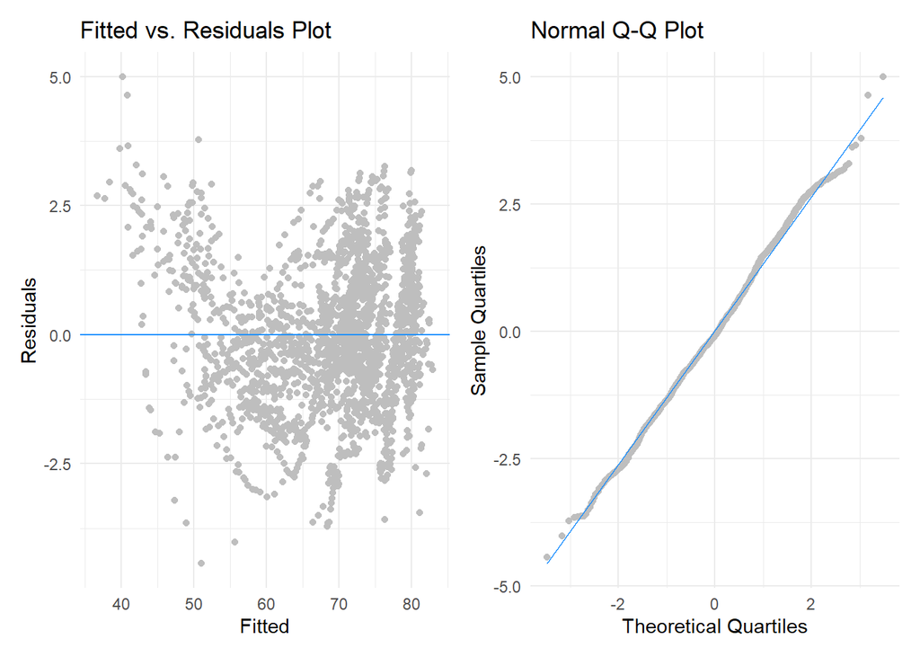

```r
data_bic = data_trn %>%
  select("Under_five_deaths", "Adult_mortality", "Alcohol_consumption", "BMI", "Incidents_HIV", "GDP_per_capita", "Thinness_ten_nineteen_years",
         "Schooling", "Developed", "Life_expectancy")
# pairs(data_bic, col = 'dodgerblue')

formula_bic = formula(add_back_bic_mod)

#
add_back_bic_mod2 = lm(Life_expectancy ~ poly(Under_five_deaths, 2) + Adult_mortality + Alcohol_consumption + BMI +
                         Incidents_HIV + log(GDP_per_capita) + Thinness_ten_nineteen_years + Schooling + Developed,
                       data = data_trn)

# diagnostics(add_back_bic_mod2)
# summary(add_back_bic_mod2)
```

```r
# BP test

bptest(add_back_bic_mod)$p.value # e-31
```

```
##        BP
## 6.497e-31
```

```r
bptest(add_back_bic_mod2)$p.value # e-45
```

```
##        BP
## 4.215e-45
```

```r
# Shapiro test
shapiro.test(add_back_bic_mod$residuals)$p.value # 0.0026
```

```
## [1] 0.002626
```

```r
shapiro.test(add_back_bic_mod2$residuals)$p.value # 0.01874
```

```
## [1] 0.01874
```

## Model Comparisons

```r
# AIC
aics = c(
  AIC(add_mod_small), # 6930
  AIC(add_back_aic_mod), ## 6914
  AIC(add_back_bic_mod), # 6918
  AIC(add_back_bic_mod2)
)

# BIC
bics = c(
  BIC(add_mod_small), # 7098
  BIC(add_back_aic_mod), # 6981
  BIC(add_back_bic_mod), ## 6980
  BIC(add_back_bic_mod2)
)

# AdjR2
adjR2s = c(
  summary(add_mod_small)$adj, ## 0.9793
  summary(add_back_aic_mod)$adj, ## 0.9793
  summary(add_back_bic_mod)$adj, # 0.9792
  summary(add_back_bic_mod2)$adj
)

# LOOCV RMSE
loocv_rmses = c(
  calc_loocv_rmse(add_mod_small), # 1.367
  calc_loocv_rmse(add_back_aic_mod), ## 1.362
  calc_loocv_rmse(add_back_bic_mod), # 1.364
  calc_loocv_rmse(add_back_bic_mod2)
)

life_models = c("Additive Model", "Backward AIC Model", "Backward BIC Model", "Backward BIC Model V2")
criterions = data.frame(life_models, aics, bics, adjR2s, loocv_rmses)
colnames(criterions) = c("Model", "AIC", "BIC", "Adj R^2", "LOOCV RMSE")
```

```r
# Train/Test RMSE
train_error = c(
  rmse(data_trn$Life_expectancy, predict(add_mod_small, data_trn)),
  rmse(data_trn$Life_expectancy, predict(add_back_aic_mod, data_trn)),
  rmse(data_trn$Life_expectancy, predict(add_back_bic_mod, data_trn)),
  rmse(data_trn$Life_expectancy, predict(add_back_bic_mod2, data_trn))
)

test_error = c(
  rmse(data_tst$Life_expectancy, predict(add_mod_small, data_tst)),
  rmse(data_tst$Life_expectancy, predict(add_back_aic_mod, data_tst)),
  rmse(data_tst$Life_expectancy, predict(add_back_bic_mod, data_tst)),
  rmse(data_tst$Life_expectancy, predict(add_back_bic_mod2, data_tst))
)

life_models = c("Additive Model", "Backward AIC Model", "Backward BIC Model", "Backward BIC Model V2")
life_results = data.frame(life_models, train_error, test_error)
colnames(life_results) = c("Model", "Train RMSE", "Test RMSE")
```

# Results

| Model | AIC | BIC | Adj R^2 | LOOCV RMSE |
| --- | --- | --- | --- | --- |
| Additive Model | 6930 | 7098 | 0.9793 | 1.367 |
| Backward AIC Model | 6914 | 6981 | 0.9793 | 1.362 |
| Backward BIC Model | 6918 | 6980 | 0.9792 | 1.364 |
| Backward BIC Model V2 | 6703 | 6770 | 0.9813 | 1.292 |

| Model | Train RMSE | Test RMSE |
| --- | --- | --- |
| Additive Model | 1.347 | 1.412 |
| Backward AIC Model | 1.353 | 1.419 |
| Backward BIC Model | 1.356 | 1.416 |
| Backward BIC Model V2 | 1.284 | 1.342 |

# Appendix

```r
high_vif = function(model){
  vif_vals = faraway::vif(model)
  vif_vals[vif_vals > 5]
}

calc_loocv_rmse = function(model) {
  sqrt(mean((resid(model) / (1 - hatvalues(model))) ^ 2))
}

influential_proportion = function(model){
  mean(cooks.distance(model) > 4 / length(resid(model)))
}

rmse = function(actual, predicted){
  sqrt(mean((actual - predicted)^2))
}

outlier_proportion = function(model){
  mean(rstandard(model)[abs(rstandard(model)) > 2])
}
```

```r
diagnostics = function(model, pcol = 'grey', lcol = 'dodgerblue', alpha = 0.01, plotit = TRUE, testit = TRUE){

  # Create individual diagnostic components

  # Fitted vs Residuals plot
  p1 = ggplot(model, aes(x = .fitted, y = .resid)) +
    geom_point(color = pcol) +
    geom_hline(yintercept = 0, color = lcol) +
    theme_minimal() +
    labs(x = 'Fitted',
         y = 'Residuals',
         title = 'Fitted vs. Residuals Plot')

  # Normal Q-Q Plot
  p2 = ggplot(model, aes(sample = .resid)) +
    geom_qq(color = pcol) +
    geom_qq_line(color = lcol) +
    theme_minimal() +
    labs(x = 'Theoretical Quartiles',
         y = 'Sample Quartiles',
         title = 'Normal Q-Q Plot')

  # Combine plots side by side
  p_final = p1 + p2


  # p-value and decision
  p_val = shapiro.test(model$residuals)$p.value
  decision = if_else(p_val < alpha, 'Reject', 'Fail to Reject')


  # Logic for which diagnostics should be returned by function
  output = list('p_val' = p_val, 'decision' = decision, 'plots' = p_final)

  if(plotit == TRUE & testit == TRUE){
    return(output)
  }
  else if(plotit == TRUE & testit == FALSE){
    return(output[3])
  }
  else if(plotit == FALSE & testit == TRUE){
    return(output[1:2])
  }

}
```

Analysis written by Maxim Aldaranov, Alice Fu, and Scott Girten